# 예스24 국내도서 중 자기계발 분야 도서 정보 분석

국철훈

2025-06-09

# 프로젝트 개요

- 목적: 자기계발 도서 시장의 가격, 출판사, 출간 추이 등 주요 특징 파악
- 배경: 디지털 콘텐츠 시대, 자기계발 도서 출판 변화에 대한 통계적 분석 필요
- 데이터 출처: 예스24에서 수집한 자기계발 분야 2000~2024년 국내도서 약 44,000권

# 1. 라이브러리 로드 및 폰트 설정

```r
library(dplyr)
library(ggplot2)
library(stringr)
library(lubridate)
library(tidyr)
library(scales)
library(gridExtra)
library(forcats)
library(extrafont)
library(patchwork)
library(purrr)
library(broom)
library(forecast)
library(tseries)
library(rstatix)
library(car)
library(zoo)

loadfonts(device = "win")
```

# 2. 데이터 불러오기 및 정제

- 가격 40,000원 이하인 도서만 포함
- 세트, 전집, 사전, 큰글책 등 제외
- 중복 도서 제거
- 출간연도 2000년~2024년 도서만 남김
- 쪽수 정보가 있는 경우 추출 후 10쪽 이하 도서는 제외합니다.

```r
all_detailed_books <- readRDS("all_detailed_books.rds")

all_detailed_books2 <- all_detailed_books %>%
  mutate(가격_숫자 = as.numeric(gsub("[^0-9]", "", 가격))) %>%
  filter(가격_숫자 > 0 & 가격_숫자 <= 40000) %>%
  filter(!str_detect(책_제목, regex("세트|set|사전|\\+|전집|큰글", ignore_case = TRUE)))

category_counts <- all_detailed_books2 %>%
  count(서브카테고리, name = "서브카테고리_책수")

all_detailed_books2 <- all_detailed_books2 %>%
  left_join(category_counts, by = "서브카테고리") %>%
  group_by(책_제목, 출판사, 저자) %>%
  slice_min(order_by = 서브카테고리_책수, with_ties = FALSE) %>%
  ungroup() %>%
  arrange(desc(서브카테고리_책수))

books_eda <- all_detailed_books2 %>%
  mutate(출간연도 = as.integer(str_extract(출간일, "^\\d{4}"))) %>%
  filter(!is.na(출간연도), 출간연도 >= 2000, 출간연도 <= 2024)

 extract_pages <- function(detail_info) {
  if (is.list(detail_info) &&
      "품목정보_테이블" %in% names(detail_info) &&
      length(detail_info$품목정보_테이블) >= 2) {

    품목정보 <- detail_info$품목정보_테이블

    if ("X2" %in% colnames(품목정보)) {
      page_str <- 품목정보$X2[2]
      if (!is.na(page_str) && is.character(page_str) && str_detect(page_str, "\\d+[\\d,]*쪽")) {
        numeric_str <- str_remove_all(page_str, ",")
        return(as.numeric(str_extract(numeric_str, "\\d+")))
      } else {
        return(NA_real_)
      }
    } else {
      return(NA_real_)
    }

  } else {
    return(NA_real_)
  }
}

books_eda <- books_eda %>%
  mutate(쪽수 = map_dbl(상세정보, extract_pages)) %>%
  filter(!is.na(쪽수), 쪽수 > 10)
```

# 3. 추가 전처리 및 변수 생성

- 저자명, 출판사명 결측값 대체
- 출간연도, 출간월, 출간연월 생성
- 가격숫자 변수명 수정

```r
books_eda <- books_eda %>%
  mutate(
    저자 = ifelse(is.na(저자), "저자 정보 없음", 저자),
    출판사 = ifelse(is.na(출판사), "출판사 정보 없음", 출판사),
    출간연도 = as.numeric(str_extract(출간일, "^\\d{4}")),
    출간월 = str_extract(출간일, "(?<=년 )\\d{2}"),
    출간연월 = paste0(출간연도, "-", 출간월)
  ) %>%
  filter(!is.na(출간연도))

names(books_eda)[names(books_eda) == "가격_숫자"] <- "가격숫자"
```

# 4. 출간 연도별 도서 수 및 출판사별 출간 도서 수 상위 5개 출판사의 도서 수 시각화

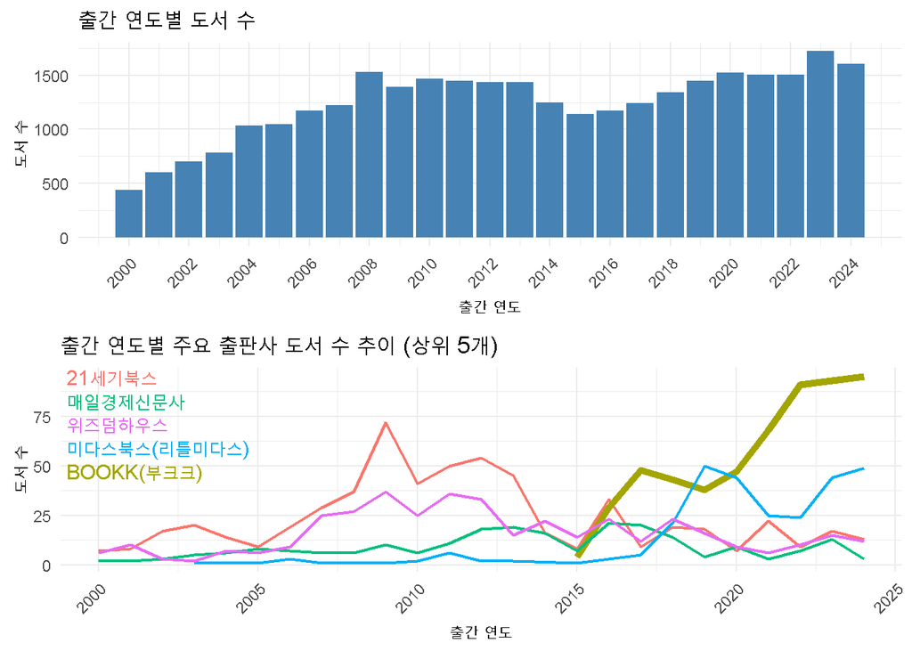

```r
eda1 <- books_eda %>%
  count(출간연도) %>%
  ggplot(aes(x = 출간연도, y = n)) +
  geom_col(fill = "steelblue") +
  scale_x_continuous(breaks = seq(min(books_eda$출간연도), max(books_eda$출간연도), by = 2)) +
  labs(title = "출간 연도별 도서 수", x = "출간 연도", y = "도서 수") +
  theme_minimal() +
  theme(axis.text.x = element_text(angle = 45, hjust = 1))

#주요 출판사별 연도별 출간 도서 수 추이 시각화
top_publishers <- books_eda %>%
  filter(!is.na(출판사)) %>%
  count(출판사, name = "도서수") %>%
  arrange(desc(도서수)) %>%
  slice_head(n = 5) %>%
  pull(출판사)

min_year <- 2000
max_year <- 2024

plot1 <- books_eda %>%
  filter(출판사 %in% top_publishers, !is.na(출간연도), 출간연도 >= min_year, 출간연도 <= max_year) %>%
  count(출간연도, 출판사, name = "도서수") %>%
  mutate(선굵기 = ifelse(출판사 == "BOOKK(부크크)", 1.8, 0.8),
         강조색상 = ifelse(출판사 == "BOOKK(부크크)", "BOOKK(부크크)", "기타"))

max_count <- max(plot1$도서수, na.rm = TRUE)

label_positions <- data.frame(
  출판사 = unique(plot1$출판사),
  y_pos = seq(max_count, max_count * 0.5, length.out = length(unique(plot1$출판사)))
)

plot1 <- plot1 %>%
  ggplot(aes(x = 출간연도, y = 도서수, group = 출판사)) +
  geom_line(aes(color = 출판사, size = 선굵기)) +
  scale_size_identity() +
  geom_text(data = label_positions,
            aes(x = min_year - 1, y = y_pos, label = 출판사, color = 출판사),
            hjust = 0, size = 4, show.legend = FALSE) +
  coord_cartesian(xlim = c(min_year, max_year)) +
  labs(title = "출간 연도별 주요 출판사 도서 수 추이 (상위 5개)",
       x = "출간 연도", y = "도서 수") +
  theme_minimal() +
  theme(axis.text.x = element_text(angle = 45, hjust = 1),
        legend.position = "none")

grid.arrange(eda1, plot1, nrow = 2)
```

# 5. 도서 가격 산점도 및 박스플롯

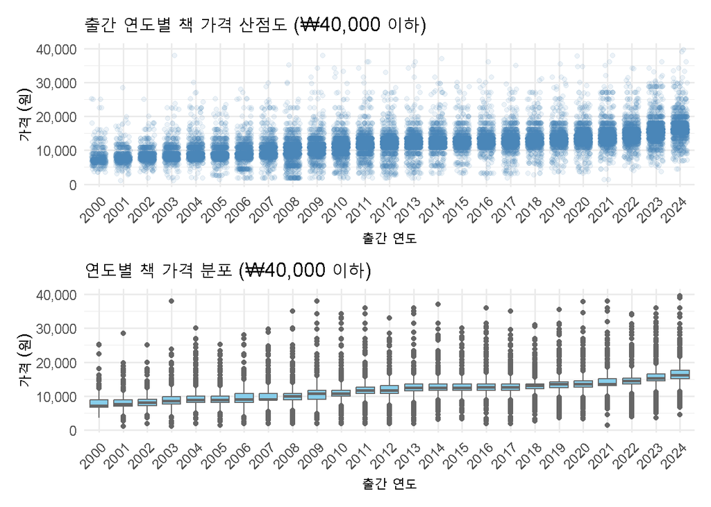

```r
max_price <- 40000

df_filtered <- books_eda %>%
  filter(!is.na(출간연도), !is.na(가격숫자), 가격숫자 > 0, 가격숫자 <= max_price)

p1 <- ggplot(df_filtered, aes(x = factor(출간연도), y = 가격숫자)) +
  geom_jitter(alpha = 0.1, color = "steelblue", width = 0.3, height = 0) +
  scale_y_continuous(labels = comma) +
  labs(
    title = "출간 연도별 책 가격 산점도 (₩40,000 이하)",
    x = "출간 연도",
    y = "가격 (원)"
  ) +
  theme_minimal(base_size = 12) +
  theme(axis.text.x = element_text(angle = 45, hjust = 1))

p2 <- ggplot(df_filtered, aes(x = factor(출간연도), y = 가격숫자)) +
  geom_boxplot(fill = "skyblue", color = "gray40") +
  scale_y_continuous(labels = comma) +
  labs(
    title = "연도별 책 가격 분포 (₩40,000 이하)",
    x = "출간 연도",
    y = "가격 (원)"
  ) +
  theme_minimal(base_size = 12) +
  theme(axis.text.x = element_text(angle = 45, hjust = 1))

library(patchwork)
p1 / p2
```

## 5-1 해석:

- 출간 연도별로 자기계발서 도서 가격 분포를 살펴보면, 가격이 0원 이상 40,000원 이하 범위에서 분포하며, 최근 연도로 갈수록 가격대가 높아지는 경향이 관찰됩니다.
- 박스플롯 중앙값이 전반적으로 상승하여 도서 가격의 중간 수준이 점차 올라가는 것으로 해석됩니다.
- 이상치 존재 여부도 박스플롯에서 확인할 수 있습니다.
- 가격 상승은 출판·유통 비용 상승, 물가 변화, 출판 시장 내 가격 정책 변화 등이 반영된 결과로 추정됩니다.

# 6.서브카테고리별 연도별 평균 및 중앙값 가격 변화

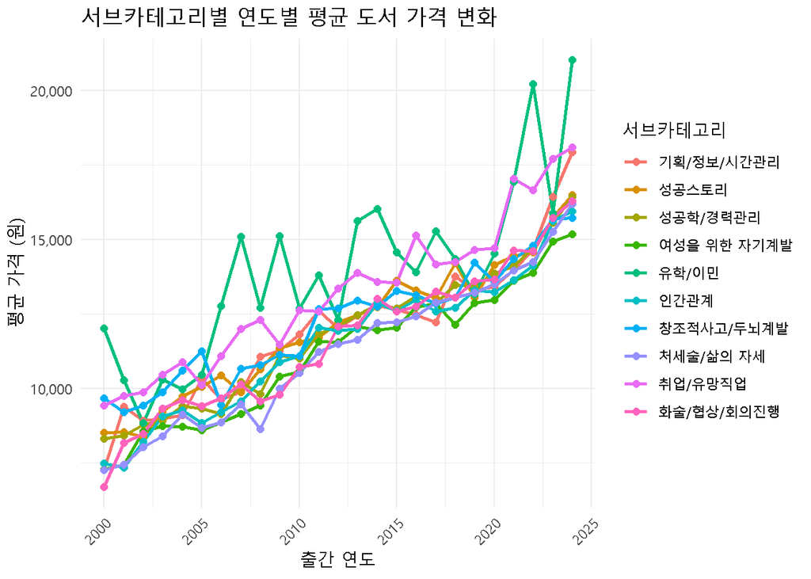

```r
price_summary <- df_filtered %>%
  group_by(출간연도, 서브카테고리) %>%
  summarise(
    평균가격 = mean(가격숫자, na.rm = TRUE),
    중앙값가격 = median(가격숫자, na.rm = TRUE),
    도서수 = n()
  ) %>%
  ungroup()

p_mean <- ggplot(price_summary, aes(x = 출간연도, y = 평균가격, color = 서브카테고리)) +
  geom_line(size = 1) +
  geom_point(size = 2) +
  scale_y_continuous(labels = comma) +
  labs(
    title = "서브카테고리별 연도별 평균 도서 가격 변화",
    x = "출간 연도",
    y = "평균 가격 (원)",
    color = "서브카테고리"
  ) +
  theme_minimal(base_family = "Malgun Gothic") +
  theme(axis.text.x = element_text(angle = 45, hjust = 1))

print(p_mean)
```

```r
print("'유학/이민' 분야와 '취업/유망직업' 분야가 꾸준히 높은 평균 가격을 기록")
```

```
## [1] "'유학/이민' 분야와 '취업/유망직업' 분야가 꾸준히 높은 평균 가격을 기록"
```

## 6-1. 해석

- ‘유학/이민’과 ’취업/유망직업’ 분야는 거의 매년 1위나 2위를 차지하며 다른 분야에 비해 평균 가격이 지속적으로 높게 나타남
- 나머지 분야들은 평균 가격 순위가 해마다 변동하는 경향이 있음

# 7.서브카테고리별 가격 분포 및 ANOVA 분석

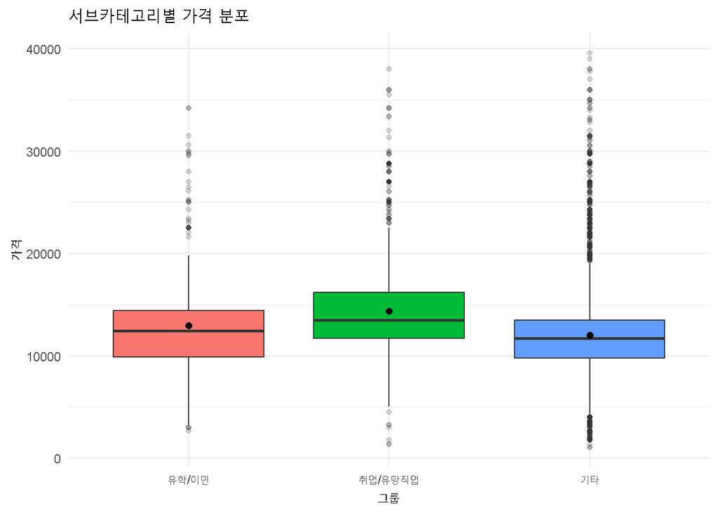

```r
df_group <- books_eda %>%
  filter(!is.na(가격숫자), 가격숫자 > 0) %>%
  mutate(
    그룹 = case_when(
      서브카테고리 == "유학/이민" ~ "유학/이민",
      서브카테고리 == "취업/유망직업" ~ "취업/유망직업",
      TRUE ~ "기타"
    )
  )

df_group$그룹 <- factor(df_group$그룹, levels = c("유학/이민", "취업/유망직업", "기타"))

ggplot(df_group, aes(x = 그룹, y = 가격숫자, fill = 그룹)) +
  geom_boxplot(outlier.alpha = 0.2) +
  stat_summary(fun = mean, geom = "point", shape = 20, size = 3, color = "black") +
  labs(title = "서브카테고리별 가격 분포",
       x = "그룹", y = "가격") +
  theme_minimal() +
  theme(legend.position = "none")
```

```r
summary_stats <- df_group %>%
  group_by(그룹) %>%
  summarise(
    개수 = n(),
    평균 = mean(가격숫자),
    표준편차 = sd(가격숫자)
  )
print(summary_stats)
```

```
## # A tibble: 3 × 4
##   그룹           개수   평균 표준편차
##   <fct>         <int>  <dbl>    <dbl>
## 1 유학/이민       456 12970.    4888.
## 2 취업/유망직업  1712 14386.    4784.
## 3 기타          28993 12017.    3543.
```

```r
print("그룹별로 데이터 수가 크게 달라 등분산 위배될 가능성이 높다")
```

```
## [1] "그룹별로 데이터 수가 크게 달라 등분산 위배될 가능성이 높다"
```

```r
print("등분산 검정 수행")
```

```
## [1] "등분산 검정 수행"
```

```r
levene_result <- df_group %>%
  levene_test(가격숫자 ~ 그룹, center = "median")
print(levene_result)
```

```
## # A tibble: 1 × 4
##     df1   df2 statistic        p
##   <int> <int>     <dbl>    <dbl>
## 1     2 31158      76.7 6.05e-34
```

```r
cat("등분산 검정 결과:\n",
    "귀무가설(H₀): 각 그룹(유학/이민, 취업/유망직업, 기타)의 분산은 동일하다.\n",
    "대립가설(H₁): 적어도 하나의 그룹은 분산이 다르다.\n\n",
    "Levene’s Test 결과 p < 0.05로, 귀무가설을 기각한다.\n",
    "→ 따라서 등분산 가정이 위배되었으므로 Welch의 ANOVA 및 Games-Howell 사후검정을 사용한다.\n")
```

```
## 등분산 검정 결과:
##  귀무가설(H₀): 각 그룹(유학/이민, 취업/유망직업, 기타)의 분산은 동일하다.
##  대립가설(H₁): 적어도 하나의 그룹은 분산이 다르다.
##
##  Levene’s Test 결과 p < 0.05로, 귀무가설을 기각한다.
##  → 따라서 등분산 가정이 위배되었으므로 Welch의 ANOVA 및 Games-Howell 사후검정을 사용한다.
```

```r
welch_result <- oneway.test(가격숫자 ~ 그룹, data = df_group, var.equal = FALSE)
print(welch_result)
```

```
##
##  One-way analysis of means (not assuming equal variances)
##
## data:  가격숫자 and 그룹
## F = 210.55, num df = 2.00, denom df = 983.38, p-value < 2.2e-16
```

```r
cat("Welch ANOVA 결과:\n",
    "귀무가설(H₀): 세 그룹(유학/이민, 취업/유망직업, 기타)의 평균 가격은 모두 같다.\n",
    "대립가설(H₁): 적어도 하나의 그룹 평균 가격은 다르다.\n\n",
    "Welch의 ANOVA 결과 p < 0.05로, 귀무가설을 기각한다.\n",
    "→ 세 그룹 간 평균 가격은 통계적으로 유의미한 차이가 있다.\n")
```

```
## Welch ANOVA 결과:
##  귀무가설(H₀): 세 그룹(유학/이민, 취업/유망직업, 기타)의 평균 가격은 모두 같다.
##  대립가설(H₁): 적어도 하나의 그룹 평균 가격은 다르다.
##
##  Welch의 ANOVA 결과 p < 0.05로, 귀무가설을 기각한다.
##  → 세 그룹 간 평균 가격은 통계적으로 유의미한 차이가 있다.
```

```r
games_howell_result <- df_group %>%
  games_howell_test(가격숫자 ~ 그룹)
print(games_howell_result)
```

```
## # A tibble: 3 × 8
##   .y.      group1       group2 estimate conf.low conf.high    p.adj p.adj.signif
## * <chr>    <chr>        <chr>     <dbl>    <dbl>     <dbl>    <dbl> <chr>
## 1 가격숫자 유학/이민    취업/…    1415.     813.     2018. 1.4 e- 7 ****
## 2 가격숫자 유학/이민    기타      -954.   -1494.     -413. 1.17e- 4 ***
## 3 가격숫자 취업/유망직… 기타     -2369.   -2645.    -2094. 1.4 e-11 ****
```

```r
cat("Games-Howell 사후검정 결과:\n",
    "- '유학/이민' vs '기타', '취업/유망직업' vs '기타' 간 평균 가격 차이가 통계적으로 유의하다 (p < 0.05).\n",
    "- '유학/이민'과 '취업/유망직업' 간 차이도 유의하고, 두 분야 모두 기타에 비해 평균 가격이 높다.\n\n",
    "→ 따라서 해당 두 분야는 다른 서브카테고리에 비해 유의하게 높은 가격대를 유지하고 있다고 볼 수 있다.\n")
```

```
## Games-Howell 사후검정 결과:
##  - '유학/이민' vs '기타', '취업/유망직업' vs '기타' 간 평균 가격 차이가 통계적으로 유의하다 (p < 0.05).
##  - '유학/이민'과 '취업/유망직업' 간 차이도 유의하고, 두 분야 모두 기타에 비해 평균 가격이 높다.
##
##  → 따라서 해당 두 분야는 다른 서브카테고리에 비해 유의하게 높은 가격대를 유지하고 있다고 볼 수 있다.
```

## 7-1. 요약 및 시사점

- 도서 가격은 분야별로 차이가 있으며, 특정 분야는 꾸준히 높은 가격 수준을 유지함
- 이러한 차이는 ‘유학/이민’ 분야는 해외 유학, 이민 준비와 관련된 전문 정보가 많아 상대적으로 고가의 전문서적이 많고, ‘취업/유망직업’ 분야는 직업 준비 및 경력 개발에 필요한 실용적 정보가 많아 시장 수요가 꾸준하고 전문성 높은 콘텐츠가 가격 상승 요인으로 작용하기 때문으로 해석할 수 있음

# 8. 월별 명목 평균 가격 시계열그림과 출간연도별 책 쪽수 박스플롯

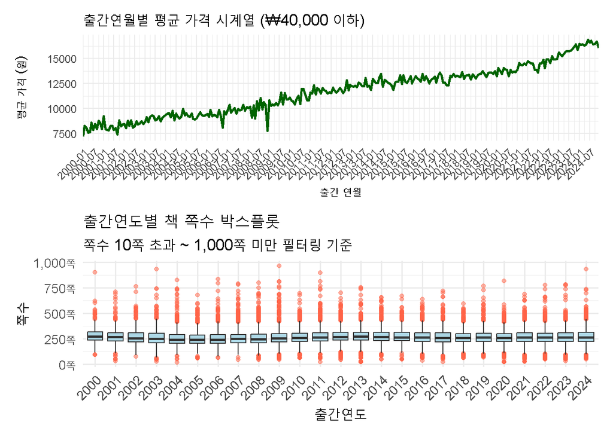

```r
#시계열그림
books_eda <- books_eda %>%
  mutate(
    출간연월_날짜 = ym(paste0(출간연도, "-", ifelse(is.na(출간월), "01", 출간월)))
  ) %>%
  filter(!is.na(출간연월_날짜))

monthly_price <- books_eda %>%
  filter(
    !is.na(가격숫자),
    가격숫자 <= max_price,
    출간연월_날짜 >= as.Date("2000-01-01")
  ) %>%
  group_by(출간연월_날짜) %>%
  summarise(평균가격 = mean(가격숫자, na.rm = TRUE)) %>%
  ungroup()

q <- ggplot(monthly_price, aes(x = 출간연월_날짜, y = 평균가격)) +
  geom_line(color = "darkgreen", size = 1) +
  labs(title = "출간연월별 평균 가격 시계열 (₩40,000 이하)",
       x = "출간 연월", y = "평균 가격 (원)") +
  theme_minimal() +
  scale_x_date(date_labels = "%Y-%m", date_breaks = "6 months", expand = c(0, 0)) +
  theme(axis.text.x = element_text(angle = 45, hjust = 1))

#박스플롯
extract_pages <- function(detail_info) {
  if (is.list(detail_info) &&
      "품목정보_테이블" %in% names(detail_info) &&
      length(detail_info$품목정보_테이블) >= 2) {
    page_str <- detail_info$품목정보_테이블$X2[2]
    if (!is.na(page_str) && is.character(page_str) && str_detect(page_str, "\\d+[\\d,]*쪽")) {
      numeric_str <- str_remove_all(page_str, ",")
      as.numeric(str_extract(numeric_str, "\\d+"))
    } else {
      NA_real_
    }
  } else {
    NA_real_
  }
}

df_real <- books_eda %>%
  mutate(
    쪽수 = map_dbl(상세정보, extract_pages)
  ) %>%
  filter(!is.na(쪽수), 쪽수 > 10, 쪽수 < 1000, 출간연도 >= 2000)

w <- ggplot(df_real, aes(x = factor(출간연도), y = 쪽수)) +
  geom_boxplot(fill = "lightblue", outlier.color = "tomato", outlier.alpha = 0.5) +
  scale_y_continuous(labels = comma_format(suffix = "쪽")) +
  labs(
    title = "출간연도별 책 쪽수 박스플롯",
    subtitle = "쪽수 10쪽 초과 ~ 1,000쪽 미만 필터링 기준",
    x = "출간연도",
    y = "쪽수"
  ) +
  theme_minimal(base_size = 13) +
  theme(axis.text.x = element_text(angle = 45, hjust = 1))

q / w
```

## 8-1. 분석

- 평균가격 우상향의 주요 원인으로 물가상승으로 인한 인플레이션과 도서의 쪽수의 증가를 생각해볼 수 있다.
- 이에 쪽수 박스플롯을 그려본 결과 쪽수의 영향은 미미해보였다.
- 이후 통계청의 출판물 물가지수를 활용해 실질 평균가격을 구해 물가영향을 제외한 시계열을 그려보았다.

# 9. 명목가격 및 실질가격 연월 구간별 추세 분석(2020년 1월 기준)

- 가변수(시기: 2020년 1월 전후)와 교호작용항을 포함한 다중 회귀분석(시간과 시기) 모델

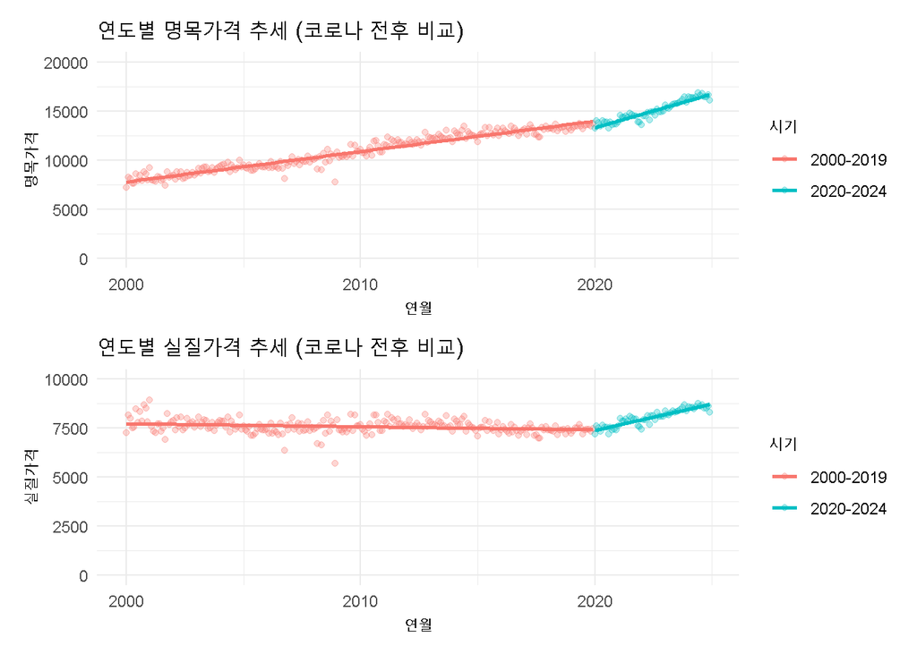

```r
#-------------------------#
# 1. 명목가격 시계열 처리
#-------------------------#

price_ts <- ts(monthly_price$평균가격,
               start = c(year(min(monthly_price$출간연월_날짜)),
                         month(min(monthly_price$출간연월_날짜))),
               frequency = 12)

nominal_price_df <- data.frame(
  연월 = as.Date(as.yearmon(time(price_ts))),
  명목가격 = as.numeric(price_ts)
) %>%
  filter(연월 >= as.Date("2000-01-01")) %>%
  mutate(
    시기 = ifelse(year(연월) < 2020, "2000-2019", "2020-2024"),
    시기 = factor(시기, levels = c("2000-2019", "2020-2024")),
    연월_num = as.numeric(연월)
  )


#-------------------------#
# 2. 실질가격 시계열 처리
#-------------------------#

# 출판물 물가지수 불러오기
cpi_books <- read.csv("C:/바탕에서 옮긴 것/캡스톤디자인/출판물 물가지수.csv")
cpi_values <- as.numeric(cpi_books[1, 3:318])

cpi_books_ts <- ts(cpi_values, start = c(2000, 1), frequency = 12)
cpi_books_ts <- window(cpi_books_ts, start = c(2000, 1), end = c(2024, 12))
base_cpi <- cpi_books_ts[1]
cpi_books_index <- (cpi_books_ts / base_cpi) * 100

real_price_ts <- price_ts / (cpi_books_index / 100)

real_price_df <- data.frame(
  연월 = as.Date(as.yearmon(time(real_price_ts))),
  실질가격 = as.numeric(real_price_ts)
) %>%
  filter(
    실질가격 <= 40000,
    연월 >= as.Date("2000-01-01")
  ) %>%
  mutate(
    시기 = ifelse(year(연월) < 2020, "2000-2019", "2020-2024"),
    시기 = factor(시기, levels = c("2000-2019", "2020-2024")),
    연월_num = as.numeric(연월)
  )
#-------------------------#
# 3. 시각화
#-------------------------#

p_nominal <- ggplot(nominal_price_df, aes(x = 연월, y = 명목가격, color = 시기)) +
  geom_point(alpha = 0.3) +
  geom_smooth(method = "lm", se = FALSE) +
  labs(title = "연도별 명목가격 추세 (코로나 전후 비교)", x = "연월", y = "명목가격") +
  theme_minimal() +
  coord_cartesian(ylim = c(0, 20000))

p_real <- ggplot(real_price_df, aes(x = 연월, y = 실질가격, color = 시기)) +
  geom_point(alpha = 0.3) +
  geom_smooth(method = "lm", se = FALSE) +
  labs(title = "연도별 실질가격 추세 (코로나 전후 비교)", x = "연월", y = "실질가격") +
  theme_minimal() +
  coord_cartesian(ylim = c(0, 10000))

# 두 그래프 함께 출력
p_nominal / p_real
```

```r
# 명목가격 회귀모형 및 ANOVA
lm_nominal <- lm(명목가격 ~ 연월_num * 시기, data = nominal_price_df)
Anova(lm_nominal, type = 3)
```

```
## Anova Table (Type III tests)
##
## Response: 명목가격
##                  Sum Sq  Df  F value    Pr(>F)
## (Intercept)    10811738   1   52.337 4.026e-12 ***
## 연월_num      765521849   1 3705.720 < 2.2e-16 ***
## 시기           17048504   1   82.528 < 2.2e-16 ***
## 연월_num:시기  17391596   1   84.189 < 2.2e-16 ***
## Residuals      61147223 296
## ---
## Signif. codes:  0 '***' 0.001 '**' 0.01 '*' 0.05 '.' 0.1 ' ' 1
```

```r
cat("명목가격 회귀 분석 결과:\n",
    "- 귀무가설(H₀): '코로나 이전(2000–2019)'과 '이후(2020–2024)' 간의 가격 상승 추세(기울기)는 동일하다.\n",
    "- 대립가설(H₁): 두 시기의 가격 상승 추세는 다르다.\n\n",
    "→ ANOVA 결과에서 상호작용항(연월_num:시기)의 p-value < 0.05로 유의수준 5%에서 귀무가설을 기각할 수 있다.\n",
    "즉, 코로나 이전과 이후의 명목가격 상승 추세는 통계적으로 유의하게 다르다고 해석할 수 있다.\n"
)
```

```
## 명목가격 회귀 분석 결과:
##  - 귀무가설(H₀): '코로나 이전(2000–2019)'과 '이후(2020–2024)' 간의 가격 상승 추세(기울기)는 동일하다.
##  - 대립가설(H₁): 두 시기의 가격 상승 추세는 다르다.
##
##  → ANOVA 결과에서 상호작용항(연월_num:시기)의 p-value < 0.05로 유의수준 5%에서 귀무가설을 기각할 수 있다.
##  즉, 코로나 이전과 이후의 명목가격 상승 추세는 통계적으로 유의하게 다르다고 해석할 수 있다.
```

```r
# 실질가격 회귀모형 및 ANOVA
lm_real <- lm(실질가격 ~ 연월_num * 시기, data = real_price_df)
Anova(lm_real, type = 3)
```

```
## Anova Table (Type III tests)
##
## Response: 실질가격
##                  Sum Sq  Df  F value    Pr(>F)
## (Intercept)   329965957   1 3469.826 < 2.2e-16 ***
## 연월_num        1941139   1   20.413  9.03e-06 ***
## 시기            9125474   1   95.961 < 2.2e-16 ***
## 연월_num:시기   9941456   1  104.541 < 2.2e-16 ***
## Residuals      28148363 296
## ---
## Signif. codes:  0 '***' 0.001 '**' 0.01 '*' 0.05 '.' 0.1 ' ' 1
```

```r
cat("실질가격 회귀 분석 결과:\n",
    "- 귀무가설(H₀): '코로나 이전(2000–2019)'과 '이후(2020–2024)' 간의 실질가격 상승 추세는 동일하다.\n",
    "- 대립가설(H₁): 두 시기의 실질가격 상승 추세는 다르다.\n\n",
    "→ ANOVA 결과에서 상호작용항(연월_num:시기)의 p-value < 0.05로, 귀무가설을 기각한다.\n",
    "즉, 물가 상승률을 보정한 실질가격조차도 코로나 전후로 상승 추세가 통계적으로 유의하게 달라졌다고 할 수 있다.\n"
)
```

```
## 실질가격 회귀 분석 결과:
##  - 귀무가설(H₀): '코로나 이전(2000–2019)'과 '이후(2020–2024)' 간의 실질가격 상승 추세는 동일하다.
##  - 대립가설(H₁): 두 시기의 실질가격 상승 추세는 다르다.
##
##  → ANOVA 결과에서 상호작용항(연월_num:시기)의 p-value < 0.05로, 귀무가설을 기각한다.
##  즉, 물가 상승률을 보정한 실질가격조차도 코로나 전후로 상승 추세가 통계적으로 유의하게 달라졌다고 할 수 있다.
```

## 9-1. 요약 및 분석

- 명목 평균 가격은 2000년 이후 완만하게 상승함
- 2020년 1월 이후 명목가격 상승 기울기가 더욱 가팔라졌으며, 이는 통계적으로 유의미함 (p < 0.001)
- 2000년 1월 기준으로 환산한 실질 평균 가격은 2020년 1월 이전까지 비교적 안정적이었으나, 이후 유의미한 상승세로 전환됨 (p < 0.001)
- 2020년 코로나19 팬데믹 이후 재택근무 및 집콕 생활 증가 → 집에서 보내는 시간이 늘면서 자기계발서 등 자기 시간 활용 관련 도서 구매가 증가
- 심리적 불안 해소와 자기관리 욕구 증가 → 팬데믹 속 심리적 안정, 동기부여, 자기관리 관련 도서 소비 확대 가능성
- 실질 가격 상승의 의미 실질 가격 상승은 단순 물가 상승에 따른 명목 가격 변동과는 달리, 도서 가격 자체의 순수한 상승을 의미
- 2020년 이전에는 물가상승을 고려할 경우 실질 가격은 일정 수준을 유지
- 2020년 이후에는 물가상승을 고려하더라도 실질 가격이 유의하게 상승 → 이는 물가 외 요인, 예: 자기계발 수요 변화, 프리미엄 콘텐츠 선호 등 구조적 요인이 작용한 결과로 해석
- 결과적으로 자기계발 출판 시장은 수요·공급 양 측면에서 질적 전환이 일어난 구조적 변화로 이해 가능하다.
- 한계: 2020년 이후 가격 상승 추세는 통계적으로 유의하지만, 분석 구간 간 기간 차이로 인한 왜곡 가능성이 있으므로 추후 추가적인 검증이 필요하다.